# Week 02 - Data cleaning and management

you

2025/1/25

# Data Frames

Often, we encounter CSV files that don’t adhere to the standard comma (,) separator. This can happen due to various reasons like regional preferences or data entry errors.

We read in the data using read_csv, but it doesn’t look good. It’s looking for a comma (,) to separate the columns.

## Reading in Delimited Data

- This file says it’s a “.csv” or **C**omma **S**eperated **V**alues.
- We use the `head` command to see that it really isn’t. It seems the columns are separated by a hash sign (#) instead.

```r
jobseekers <- read_csv('./w01_jobseekers.csv')
head(jobseekers)
```

```
## # A tibble: 6 × 1
##   `id#FirstName#LastName#PostCode#PhoneNumber#OnMarket#NumContacts#JobSought`
##   <chr>
## 1 644#^Jasmine#al-(ID= 644)Mona#EX2 9BY#04464 17408#4#2#Emergency planning/mana…
## 2 1138#^Mazeed#Bi(ID=1138)ano#EX4 2BD#01219 91595#6#5#Nurse, learning disability
## 3 298#^Sandra#Beltra(ID= 298)n#EX2 4AY#+44(0)5700289298#2#2#Therapist, horticul…
## 4 1352#^Brooke#Harne(ID=1352)y#EX2 6HD#(07963) 168037#2#1#Media planner
## 5 343#^Tuhfa#Cho(ID= 343)ng#EX2 6BW#00065 12918#2#2#Ranger/warden
## 6 323#^Gabriela#Cowa(ID= 323)n#EX1 1NX#+44(0)4031790535#3#3#Accountant, charter…
```

```r
tail(jobseekers)
```

```
## # A tibble: 6 × 1
##   `id#FirstName#LastName#PostCode#PhoneNumber#OnMarket#NumContacts#JobSought`
##   <chr>
## 1 1159#^Alexander#al(ID=1159)-Yusuf#EX4 4XD#+44(0)4310 69090#7#5#Information of…
## 2 1143#^Daniel#el-(ID=1143)Jamil#EX2 9JX#0583729259#4#5#Scientist, marine
## 3 996#^Abdur Razzaaq#al-Mu(ID= 996)hammed#EX1 9NX#06541 578059#3#2#Trade mark a…
## 4 160#^Paris#Pu(ID= 160)revsuren#EX4 4XD#+44(0)110819093#1#2#Sports coach
## 5 753#^Salwa#River(ID= 753)a-Garfio#EX4 8PD#+44(0)778986111#3#2#Ranger/warden
## 6 331#^Nicholas#War(ID= 331)d#EX2 6HD#+44(0)3018 701288#3#2#Software engineer
```

The readr package provides a flexible function called read_delim() that allows us to specify the delimiter used in the file. By using delim = “#” within the function, we instruct R to correctly interpret the data and create a data frame.

```r
jobseekers <- read_delim('./w01_jobseekers.csv', delim="#")
head(jobseekers)
```

```
## # A tibble: 6 × 8
##      id FirstName LastName   PostCode PhoneNumber OnMarket NumContacts JobSought
##   <dbl> <chr>     <chr>      <chr>    <chr>          <dbl> <chr>       <chr>
## 1   644 ^Jasmine  al-(ID= 6… EX2 9BY  04464 17408        4 2           Emergenc…
## 2  1138 ^Mazeed   Bi(ID=113… EX4 2BD  01219 91595        6 5           Nurse, l…
## 3   298 ^Sandra   Beltra(ID… EX2 4AY  +44(0)5700…        2 2           Therapis…
## 4  1352 ^Brooke   Harne(ID=… EX2 6HD  (07963) 16…        2 1           Media pl…
## 5   343 ^Tuhfa    Cho(ID= 3… EX2 6BW  00065 12918        2 2           Ranger/w…
## 6   323 ^Gabriela Cowa(ID= … EX1 1NX  +44(0)4031…        3 3           Accounta…
```

## Summaries of data tables

The number of rows and columns.

```r
dim(jobseekers)
```

```
## [1] 1866    8
```

```r
ncol(jobseekers)
```

```
## [1] 8
```

```r
nrow(jobseekers)
```

```
## [1] 1866
```

The variable names.

```r
colnames(jobseekers)
```

```
## [1] "id"          "FirstName"   "LastName"    "PostCode"    "PhoneNumber"
## [6] "OnMarket"    "NumContacts" "JobSought"
```

```r
names(jobseekers)
```

```
## [1] "id"          "FirstName"   "LastName"    "PostCode"    "PhoneNumber"
## [6] "OnMarket"    "NumContacts" "JobSought"
```

The case names

```r
head(rownames(jobseekers))
```

```
## [1] "1" "2" "3" "4" "5" "6"
```

Structure of the object.

```r
str(jobseekers)
```

```
## spc_tbl_ [1,866 × 8] (S3: spec_tbl_df/tbl_df/tbl/data.frame)
##  $ id         : num [1:1866] 644 1138 298 1352 343 ...
##  $ FirstName  : chr [1:1866] "^Jasmine" "^Mazeed" "^Sandra" "^Brooke" ...
##  $ LastName   : chr [1:1866] "al-(ID= 644)Mona" "Bi(ID=1138)ano" "Beltra(ID= 298)n" "Harne(ID=1352)y" ...
##  $ PostCode   : chr [1:1866] "EX2 9BY" "EX4 2BD" "EX2 4AY" "EX2 6HD" ...
##  $ PhoneNumber: chr [1:1866] "04464 17408" "01219 91595" "+44(0)5700289298" "(07963) 168037" ...
##  $ OnMarket   : num [1:1866] 4 6 2 2 2 3 4 1 1 7 ...
##  $ NumContacts: chr [1:1866] "2" "5" "2" "1" ...
##  $ JobSought  : chr [1:1866] "Emergency planning/management officer" "Nurse, learning disability" "Therapist, horticultural" "Media planner" ...
##  - attr(*, "spec")=
##   .. cols(
##   ..   id = col_double(),
##   ..   FirstName = col_character(),
##   ..   LastName = col_character(),
##   ..   PostCode = col_character(),
##   ..   PhoneNumber = col_character(),
##   ..   OnMarket = col_double(),
##   ..   NumContacts = col_character(),
##   ..   JobSought = col_character()
##   .. )
##  - attr(*, "problems")=<externalptr>
```

## Using a data frame

There are a lot of different packages for managing data these days. We are using the `tibble` package in the `tidyverse`. But all of this will work with the basic data frames.

```r
?data.frame
```

There are different ways of accessing columns / variables. ** Note that R is indexed from 1, not 0 like many other programming languages**

The `dplyr` package provides a more concise and readable way to manipulate data frames, including selecting columns. We have used the `head` function in each case to return only the first six rows. Using dplyr, it is ‘chained’ using the piping operator `%>%`

```r
x <- head(jobseekers$FirstName)
y <- head(jobseekers[,'FirstName'])
head(jobseekers[, c('FirstName', 'LastName')])
```

```
## # A tibble: 6 × 2
##   FirstName LastName
##   <chr>     <chr>
## 1 ^Jasmine  al-(ID= 644)Mona
## 2 ^Mazeed   Bi(ID=1138)ano
## 3 ^Sandra   Beltra(ID= 298)n
## 4 ^Brooke   Harne(ID=1352)y
## 5 ^Tuhfa    Cho(ID= 343)ng
## 6 ^Gabriela Cowa(ID= 323)n
```

```r
head(jobseekers[['FirstName']])
```

```
## [1] "^Jasmine"  "^Mazeed"   "^Sandra"   "^Brooke"   "^Tuhfa"    "^Gabriela"
```

```r
head(jobseekers[,2])
```

```
## # A tibble: 6 × 1
##   FirstName
##   <chr>
## 1 ^Jasmine
## 2 ^Mazeed
## 3 ^Sandra
## 4 ^Brooke
## 5 ^Tuhfa
## 6 ^Gabriela
```

```r
head(jobseekers[, c(2, 3)]) # Select the second and third columns
```

```
## # A tibble: 6 × 2
##   FirstName LastName
##   <chr>     <chr>
## 1 ^Jasmine  al-(ID= 644)Mona
## 2 ^Mazeed   Bi(ID=1138)ano
## 3 ^Sandra   Beltra(ID= 298)n
## 4 ^Brooke   Harne(ID=1352)y
## 5 ^Tuhfa    Cho(ID= 343)ng
## 6 ^Gabriela Cowa(ID= 323)n
```

```r
# Using dplyr
jobseekers %>%
  select(FirstName) %>% head()
```

```
## # A tibble: 6 × 1
##   FirstName
##   <chr>
## 1 ^Jasmine
## 2 ^Mazeed
## 3 ^Sandra
## 4 ^Brooke
## 5 ^Tuhfa
## 6 ^Gabriela
```

```r
jobseekers %>%
  select(FirstName, LastName) %>% head
```

```
## # A tibble: 6 × 2
##   FirstName LastName
##   <chr>     <chr>
## 1 ^Jasmine  al-(ID= 644)Mona
## 2 ^Mazeed   Bi(ID=1138)ano
## 3 ^Sandra   Beltra(ID= 298)n
## 4 ^Brooke   Harne(ID=1352)y
## 5 ^Tuhfa    Cho(ID= 343)ng
## 6 ^Gabriela Cowa(ID= 323)n
```

… And of accessing rows / cases.

```r
jobseekers[1,]
```

```
## # A tibble: 1 × 8
##      id FirstName LastName   PostCode PhoneNumber OnMarket NumContacts JobSought
##   <dbl> <chr>     <chr>      <chr>    <chr>          <dbl> <chr>       <chr>
## 1   644 ^Jasmine  al-(ID= 6… EX2 9BY  04464 17408        4 2           Emergenc…
```

```r
jobseekers[c(1, 3, 5), ]  # Extract rows 1, 3, and 5
```

```
## # A tibble: 3 × 8
##      id FirstName LastName   PostCode PhoneNumber OnMarket NumContacts JobSought
##   <dbl> <chr>     <chr>      <chr>    <chr>          <dbl> <chr>       <chr>
## 1   644 ^Jasmine  al-(ID= 6… EX2 9BY  04464 17408        4 2           Emergenc…
## 2   298 ^Sandra   Beltra(ID… EX2 4AY  +44(0)5700…        2 2           Therapis…
## 3   343 ^Tuhfa    Cho(ID= 3… EX2 6BW  00065 12918        2 2           Ranger/w…
```

```r
jobseekers[1:5, ]  # Extract rows 1 to 5
```

```
## # A tibble: 5 × 8
##      id FirstName LastName   PostCode PhoneNumber OnMarket NumContacts JobSought
##   <dbl> <chr>     <chr>      <chr>    <chr>          <dbl> <chr>       <chr>
## 1   644 ^Jasmine  al-(ID= 6… EX2 9BY  04464 17408        4 2           Emergenc…
## 2  1138 ^Mazeed   Bi(ID=113… EX4 2BD  01219 91595        6 5           Nurse, l…
## 3   298 ^Sandra   Beltra(ID… EX2 4AY  +44(0)5700…        2 2           Therapis…
## 4  1352 ^Brooke   Harne(ID=… EX2 6HD  (07963) 16…        2 1           Media pl…
## 5   343 ^Tuhfa    Cho(ID= 3… EX2 6BW  00065 12918        2 2           Ranger/w…
```

```r
slice(jobseekers, 1:5)  # Extract rows 1 to 5 using dyplr
```

```
## # A tibble: 5 × 8
##      id FirstName LastName   PostCode PhoneNumber OnMarket NumContacts JobSought
##   <dbl> <chr>     <chr>      <chr>    <chr>          <dbl> <chr>       <chr>
## 1   644 ^Jasmine  al-(ID= 6… EX2 9BY  04464 17408        4 2           Emergenc…
## 2  1138 ^Mazeed   Bi(ID=113… EX4 2BD  01219 91595        6 5           Nurse, l…
## 3   298 ^Sandra   Beltra(ID… EX2 4AY  +44(0)5700…        2 2           Therapis…
## 4  1352 ^Brooke   Harne(ID=… EX2 6HD  (07963) 16…        2 1           Media pl…
## 5   343 ^Tuhfa    Cho(ID= 3… EX2 6BW  00065 12918        2 2           Ranger/w…
```

```r
filter(jobseekers, id < 10)  # Extract rows (based on conditions) where id column is less than 10
```

```
## # A tibble: 11 × 8
##       id FirstName  LastName PostCode PhoneNumber OnMarket NumContacts JobSought
##    <dbl> <chr>      <chr>    <chr>    <chr>          <dbl> <chr>       <chr>
##  1     9 ^Johnathon Rona(ID… EX4 4XD  04877 10922        4 5           Libraria…
##  2     9 ^Johnathon Rona(ID… EX4 4XD  04877 10922        4 5           Libraria…
##  3     5 ^Talaal    Tra(ID=… EX4 4XD  +44(0)5028…        2 2           Meteorol…
##  4     5 ^Talaal    Tra(ID=… EX4 4XD  +44(0)5028…        2 2           Meteorol…
##  5     5 ^Talaal    Tra(ID=… EX4 4XD  +44(0)5028…        2 2           Meteorol…
##  6     5 ^Talaal    Tra(ID=… EX4 4XD  +44(0)5028…        2 2           Meteorol…
##  7     9 ^Johnathon Rona(ID… EX4 4XD  04877 10922        4 5           Libraria…
##  8     9 ^Johnathon Rona(ID… EX4 4XD  04877 10922        4 5           Libraria…
##  9     9 ^Johnathon Rona(ID… EX4 4XD  04877 10922        4 5           Libraria…
## 10     5 ^Talaal    Tra(ID=… EX4 4XD  +44(0)5028…        2 2           Meteorol…
## 11     9 ^Johnathon Rona(ID… EX4 4XD  04877 10922        4 5           Libraria…
```

Note that accessing row *named* “644” is not the `id` of “644”.

```r
jobseekers['644',]
```

```
## # A tibble: 1 × 8
##      id FirstName LastName   PostCode PhoneNumber OnMarket NumContacts JobSought
##   <dbl> <chr>     <chr>      <chr>    <chr>          <dbl> <chr>       <chr>
## 1  1119 ^Hilmiyya Go(ID=111… EX4 4XD  +44(0)7055…        2 2           Horticul…
```

Get `id == 644` and all columns

```r
jobseekers[jobseekers$id == "644",]
```

```
## # A tibble: 6 × 8
##      id FirstName LastName   PostCode PhoneNumber OnMarket NumContacts JobSought
##   <dbl> <chr>     <chr>      <chr>    <chr>          <dbl> <chr>       <chr>
## 1   644 ^Jasmine  al-(ID= 6… EX2 9BY  04464 17408        4 2           Emergenc…
## 2    NA <NA>      <NA>       <NA>     <NA>              NA <NA>        <NA>
## 3   644 ^Jasmine  al-(ID= 6… EX2 9BY  04464 17408        4 2           Emergenc…
## 4    NA <NA>      <NA>       <NA>     <NA>              NA <NA>        <NA>
## 5    NA <NA>      <NA>       <NA>     <NA>              NA <NA>        <NA>
## 6   644 ^Jasmine  al-(ID= 6… EX2 9BY  04464 17408        4 2           Emergenc…
```

The best way to do this is using the `filter` function in the `dplyr` package, which is part of tidyverse. Here we are using the piping operator `%>%’ to chain operations in a clean and readable way.

`jobseekers` is the dataframe `%>%` takes the output of the previous step (in this case the data) and passes it to the first argument of the function. `filter(id == '644')` uses the `filter` function to select rows from the dataframe where the condition `id == 644`. In other words, it extracts the row(s) where the ‘id’ column has the value ‘644’.

```r
jobseekers %>%
  filter(id == '644')
```

```
## # A tibble: 3 × 8
##      id FirstName LastName   PostCode PhoneNumber OnMarket NumContacts JobSought
##   <dbl> <chr>     <chr>      <chr>    <chr>          <dbl> <chr>       <chr>
## 1   644 ^Jasmine  al-(ID= 6… EX2 9BY  04464 17408        4 2           Emergenc…
## 2   644 ^Jasmine  al-(ID= 6… EX2 9BY  04464 17408        4 2           Emergenc…
## 3   644 ^Jasmine  al-(ID= 6… EX2 9BY  04464 17408        4 2           Emergenc…
```

> Your turn: Using the same code , can you filter and find people from Post code ‘EX4 2PN’ HINT: Use the function `colnames` or look in your environment to ensure you use the correct formatting of the column header

```r
jobseekers %>%
  filter(PostCode == 'EX4 2PN')
```

```
## # A tibble: 134 × 8
##       id FirstName  LastName PostCode PhoneNumber OnMarket NumContacts JobSought
##    <dbl> <chr>      <chr>    <chr>    <chr>          <dbl> <chr>       <chr>
##  1   409 ^Ali       Bartlin… EX4 2PN  +44(0)0294…        3 2           Physiolo…
##  2   409 ^Ali       Bartlin… EX4 2PN  +44(0)0294…        3 2           Physiolo…
##  3   504 ^Xochitl   Sta(ID=… EX4 2PN  +44(0)2779…        5 5           Chief St…
##  4  1284 ^Gregory   Schi(ID… EX4 2PN  0441597924         3 2           Therapis…
##  5   101 ^Bandar    Jon(ID=… EX4 2PN  +44(0)0026…        2 1           Outdoor …
##  6   814 ^Tanner    Ho(ID= … EX4 2PN  (04481) 39…        4 3           Building…
##  7   717 ^Anjanetta Pha(ID=… EX4 2PN  01607066740        3 2           Therapis…
##  8   814 ^Tanner    Ho(ID= … EX4 2PN  (04481) 39…        4 3           Building…
##  9  1456 ^Mark      Pose(ID… EX4 2PN  +44(0)2703…        1 2           Engineer…
## 10   673 ^Michelle  Ma(ID= … EX4 2PN  (05147) 06…        3 1           Ranger/w…
## # ℹ 124 more rows
```

# Variable Types

> Check the structure of the dataframe `jobseekers` , which shows us variable types. How do they look?

```r
str(jobseekers)
```

```
## spc_tbl_ [1,866 × 8] (S3: spec_tbl_df/tbl_df/tbl/data.frame)
##  $ id         : num [1:1866] 644 1138 298 1352 343 ...
##  $ FirstName  : chr [1:1866] "^Jasmine" "^Mazeed" "^Sandra" "^Brooke" ...
##  $ LastName   : chr [1:1866] "al-(ID= 644)Mona" "Bi(ID=1138)ano" "Beltra(ID= 298)n" "Harne(ID=1352)y" ...
##  $ PostCode   : chr [1:1866] "EX2 9BY" "EX4 2BD" "EX2 4AY" "EX2 6HD" ...
##  $ PhoneNumber: chr [1:1866] "04464 17408" "01219 91595" "+44(0)5700289298" "(07963) 168037" ...
##  $ OnMarket   : num [1:1866] 4 6 2 2 2 3 4 1 1 7 ...
##  $ NumContacts: chr [1:1866] "2" "5" "2" "1" ...
##  $ JobSought  : chr [1:1866] "Emergency planning/management officer" "Nurse, learning disability" "Therapist, horticultural" "Media planner" ...
##  - attr(*, "spec")=
##   .. cols(
##   ..   id = col_double(),
##   ..   FirstName = col_character(),
##   ..   LastName = col_character(),
##   ..   PostCode = col_character(),
##   ..   PhoneNumber = col_character(),
##   ..   OnMarket = col_double(),
##   ..   NumContacts = col_character(),
##   ..   JobSought = col_character()
##   .. )
##  - attr(*, "problems")=<externalptr>
```

The `table` function is used to create a frequency table - a count of occurrences for each unique value. We can inspect the values and spot the issue.

```r
table(jobseekers$NumContacts)
```

```
##
##    1    2    3    5    6    7 five four  one  two
##  366  679  472  296   28   20    1    1    1    2
```

Converting to numeric creates some NA values … missing values. That means that some of the text values couldn’t be directly converted to numbers.

```r
as.numeric(jobseekers$NumContacts)
```

```
##    [1]  2  5  2  1  2  3  3  1  2  5  3  2  1  3  1  2  2  1  2  7  1  1  3  2
##   [25]  5  3  2  1  1  2  5  2  5  1  3  1  6  1  3  1  2  5  3  1  5  3  5  1
##   [49]  2  1  3  5  2  2  2  3  7  1  5  1  3  3  2  2  3  1  2  5  2  2  1  2
##   [73]  1  3  5  3  3  5  1  2  1  3  3  2  5  2  1  3  2  2  5  3  5  3  5  1
##   [97]  3  1  5  2  2  2  3  2  2  3  2  5  2  2  5  2  3  1  2  3  1  3  3  1
##  [121]  2  3  2  5  2  3  1  1  2  2  2  3  2  2  1  1  3  2  1  2  2  2  3  5
##  [145]  1  1  3  3  1  6  3  3  2  2  3  1  3  1  5  1  6  2  1  1  3  2  3  5
##  [169]  2  1  3  5  3  2  5  2  2  1  5  1  1  1  2  3  3  1  3  5  3  5  1  1
##  [193]  2  3  6  5  1  2  1  5  2  1  5  5  2  5  1  3  5  1  3  2  3  3  2  3
##  [217]  2  5  2  2  1  3  2  5  3  3  1  3  5  6  5  1  2  5  2  5  2  2  1  3
##  [241]  3  3  7  5  1  5  1  2  1  5  2  2  2  2  2  5  1  1  1  5  1  5  5  5
##  [265]  2  5  1  5  1  1  1  2  3  2  3  3  3  2  3  3  5  5  5  1  3  2  3  3
##  [289]  3  2  3  2  1  2  3  5  5  2  3  3  2  2  7  3  1  1  1  5  3  3  5  1
##  [313]  2  2  5  1  2  2  2  3  2  1  2  2  2  3  3  2  3  2  2  1  2  2  5  3
##  [337]  2  5  2  2  3  2  5  5  5  2  1  2  3  5  2  2  5  1  2  3  2  2  2  2
```

[output cut: 63 more lines]

We will make a frequency table that compares the orignal `NumContacts` with the values attempted by numeric conversion. It explicitly includes a category for missing values (NA) in the output, allowing you say how many values failed to convert to numeric. Setting useNA = ‘always’ instructs the function to include a category for missing values in the frequency table. This helps to identify and understand the extent of the missing data in the the `NumContacts` column after the attempted conversion.

```r
table(jobseekers$NumContacts, #the original values
      as.numeric(jobseekers$NumContacts), #our attempt to convert them to numeric makes some NA
      useNA = 'always') #instructs function to include a category for missing values
```

```
##
##          1   2   3   5   6   7 <NA>
##   1    366   0   0   0   0   0    0
##   2      0 679   0   0   0   0    0
##   3      0   0 472   0   0   0    0
##   5      0   0   0 296   0   0    0
##   6      0   0   0   0  28   0    0
##   7      0   0   0   0   0  20    0
##   five   0   0   0   0   0   0    1
##   four   0   0   0   0   0   0    1
##   one    0   0   0   0   0   0    1
##   two    0   0   0   0   0   0    2
##   <NA>   0   0   0   0   0   0    0
```

Using `dplyr` we can convert strings into numeric values using `mutate`. We will create a new dataframe called `jobseekers` which will overwrite the previous dataframe called `jobseekers`.

jobseekers %>%: This uses the pipe operator (%>%) from dplyr. It takes the jobseekers data frame and passes it to the subsequent mutate() function.

mutate(NumContacts = case_when(…)): This line creates a new NumContacts column within the data frame.

```
`case_when()` is a powerful function that allows you to conditionally modify values.
Inside case_when(), we define a series of conditions:
    NumContacts == 'five' ~ '5': If NumContacts is "five", replace it with "5".
    NumContacts == 'four' ~ '4': If NumContacts is "four", replace it with "4".
    NumContacts == 'one' ~ '1': If NumContacts is "one", replace it with "1".
    NumContacts == 'two' ~ '2': If NumContacts is "two", replace it with "2".
    T ~ NumContacts: This is the default case. If none of the previous conditions match, keep the original NumContacts value.
```

mutate(NumContacts = as.numeric(NumContacts)): This line applies the as.numeric() function to the newly modified NumContacts column. This attempts to convert the character strings (including the replaced values like “5”, “4”, etc.) into numeric values.

```r
jobseekers <- jobseekers %>%
  mutate(NumContacts = case_when(
    NumContacts == 'five' ~ '5',
    NumContacts == 'four' ~ '4',
    NumContacts == 'one' ~ '1',
    NumContacts == 'two' ~ '2',
    T ~ NumContacts #default if none of the other conditions match
  )) %>%
  mutate(NumContacts = as.numeric(NumContacts))
```

# Extreme Values

Nothing extreme here. It makes sense to have up to 7 contacts with a client.

```r
table(jobseekers$NumContacts)
```

```
##
##   1   2   3   4   5   6   7
## 367 681 472   1 297  28  20
```

But here something is different.

```r
table(jobseekers$OnMarket)
```

```
##
##  -2   1   2   3   4   5   6   7   8 200 400 500
##   6 275 457 505 359 135  64  32   6   8  12   7
```

It becomes really obvious if you plot it using `geom_histogram`

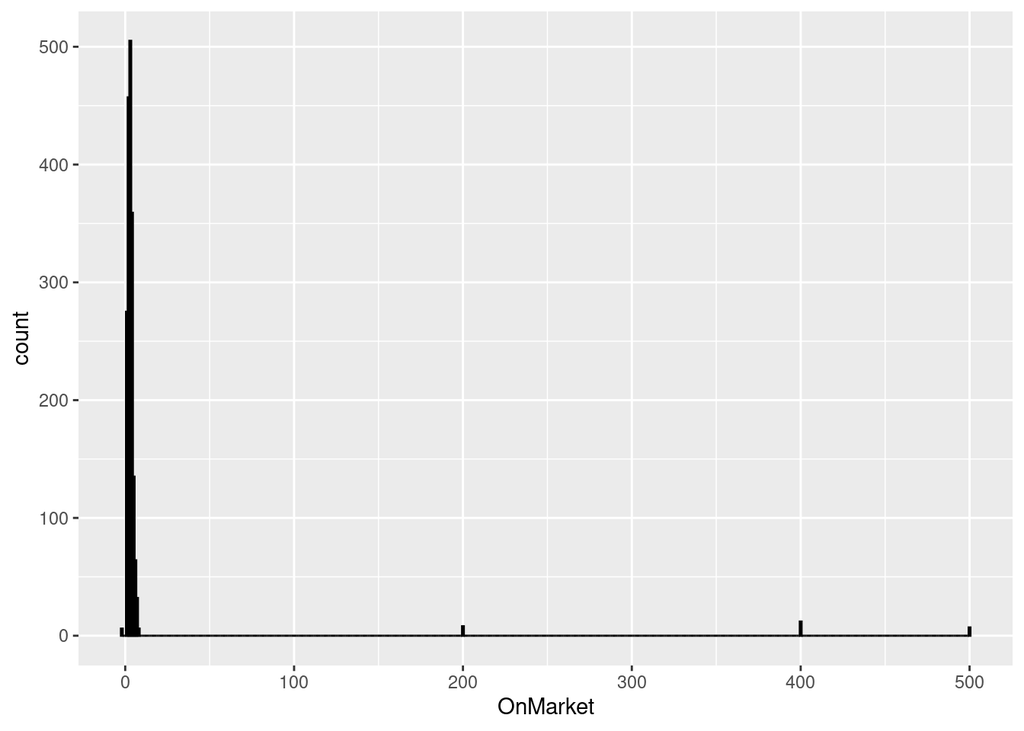

```r
ggplot(jobseekers, aes(x = OnMarket)) +
geom_histogram(binwidth = 1,
                 fill = "#69b3a2",
                 color = "black")
```

We have a decision to make. Are these errors or real values?

How do we decide how to proceed?

Let’s assume that no one can looking for a job for less than 0 years. Let’s assume that anything over 20 months is an error.

```r
jobseekers <- jobseekers %>%
  mutate(OnMarket = case_when(OnMarket > 20 ~ NA_real_,
                              OnMarket < 0 ~ NA_real_,
                              T ~ OnMarket))
```

This looks better.

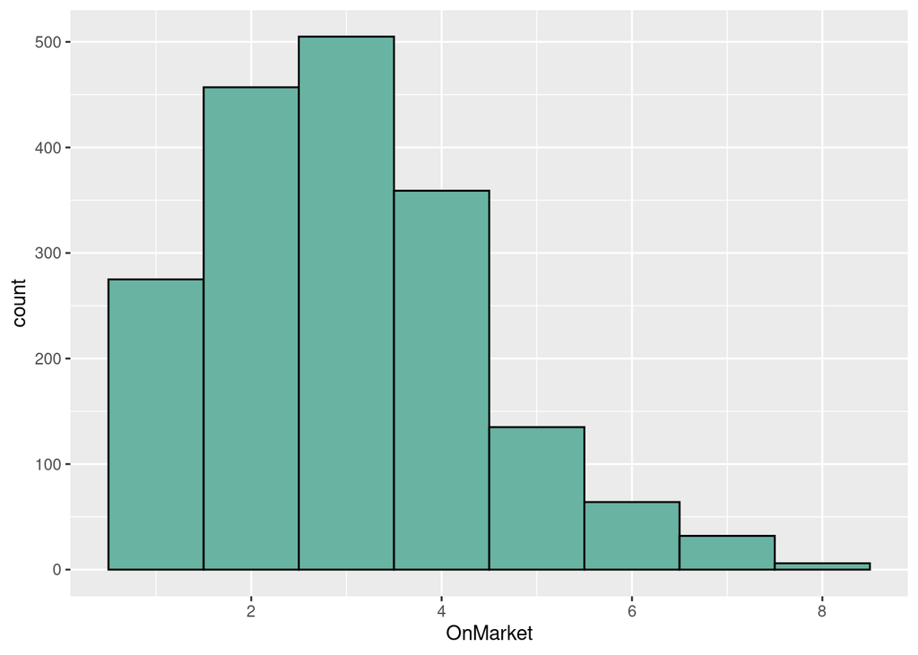

```r
ggplot(jobseekers, aes(x = OnMarket)) +
geom_histogram(binwidth = 1,
                 fill = "#69b3a2",
                 color = "black")
```

# Missing data?

Here is an example of potentially missing data. Why are there no people with 4 contacts (aside from the one we recoded from “four”)?

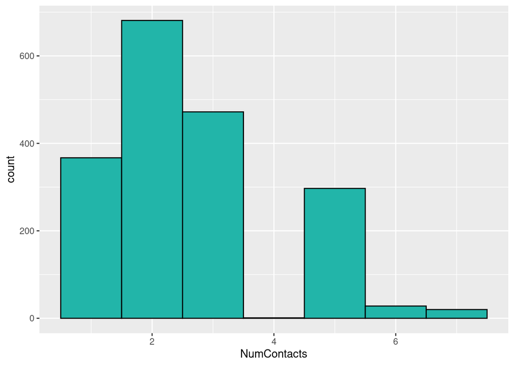

```r
ggplot(jobseekers, aes(x = NumContacts)) +
geom_histogram(binwidth = 1,
                 fill = "#22b5a9",
                 color = "black")
```

There’s often nothing to do to the data here to fix this. But maybe there’s some issue with the data that needs to be examined. Are there problems with the data collection? It’s possible that this is the real data, but it seems unlikely.

# Missing values

Missing values can be a problem. Many R functions and statistical models cannot handle missing data, which can lead to incorrect or misleading results.

The easiest way to deal with them is to remove them. However removing observations with missing values reduces the sample size.

It may also bias results, if missing values are not random (for example, people with higher incomes are less likely to report their income).

The `na.omit` function will eliminate any row that has any values of NA for any variable.

Note: we are not changing the underlying dataset here - these are just calculations: ‘What are the dimensions of the jobseekers dataset?’ ‘If we omit all rows with NA values, what are the dimensions of the jobseekers dataset?’

> How would we save the changes to the original dataset?

```r
dim(jobseekers)
```

```
## [1] 1866    8
```

```r
na.omit(jobseekers) %>%
  dim
```

```
## [1] 1824    8
```

These are the missing ID’s

```r
jobseekers[is.na(jobseekers$id),]
```

```
## # A tibble: 3 × 8
##      id FirstName LastName   PostCode PhoneNumber OnMarket NumContacts JobSought
##   <dbl> <chr>     <chr>      <chr>    <chr>          <dbl>       <dbl> <chr>
## 1    NA ^Gabriela Cowa(ID= … EX1 1NX  +44(0)4031…        3           3 Accounta…
## 2    NA ^Cameron  el-Ama(ID… EX4 6QL  +44(0)4035…        3           3 Curator
## 3    NA ^Ali      Bartlin(I… EX4 2PN  +44(0)0294…        3           2 Physiolo…
```

Now we are omitting all rows containing missing data, and saving it back to the same name. This changes the underlying dataset. It has removed 1866 - 1824 = 42 cases for missing data.

```r
jobseekers <- na.omit(jobseekers)
```

# Duplicate cases

Duplicates artificially inflate the sample size, leading to inaccurate results and misleading conclusions.

There are serious duplicates here. We use the ‘distinct’ function to return a dataframe containing only the unique rows based on the specified columns, and check its dimensions. We can compare that to the dimensions of the original dataframe.

```r
distinct(jobseekers) %>% dim
```

```
## [1] 307   8
```

```r
dim(jobseekers)
```

```
## [1] 1824    8
```

What are the results?

Here, we are using `dplr` to group the dataset by the `id` column, count the occurances for each id, and arrange the results in descending order. This identifeis potential duplicates in the dataset.

```r
jobseekers %>%
  group_by(id) %>%
  summarize(n = n()) %>%
  arrange(desc(n))
```

```
## # A tibble: 306 × 2
##       id     n
##    <dbl> <int>
##  1  1186    12
##  2  1348    12
##  3   504    11
##  4   761    11
##  5  1053    11
##  6  1134    11
##  7  1147    11
##  8  1242    11
##  9  1326    11
## 10   253    10
## # ℹ 296 more rows
```

What are the results?

We are now grouping by `id` again, which gathers together all rows with same `id`. The ‘summarize’ function creates a new variable called ‘n’ which counts the number of rows in each group (ie for each unique id). The result is a new dataframe with two columns - ‘id’ and ‘n’. We then group by ‘n’ - this now gathers all rows with the same (n) together. Finally, summarize(nn=n()) creates another new variable called ‘nn’ which again counts the number of rows with each group (ie for each unique value of ‘n’).

The result is a new dataframe (which is not saved as an object), with two columns - ‘n’ and ‘nn’ - the number of times an id is duplicated; how many id’s have that specific duplication count.

```r
jobseekers %>%
  group_by(id) %>%
  summarize(n = n()) %>%
  group_by(n) %>%
  summarize(nn = n())
```

```
## # A tibble: 12 × 2
##        n    nn
##    <int> <int>
##  1     1     2
##  2     2     8
##  3     3    32
##  4     4    44
##  5     5    48
##  6     6    56
##  7     7    43
##  8     8    34
##  9     9    16
## 10    10    14
## 11    11     7
## 12    12     2
```

We can take a quick look at the dataset with distinct entries, then save it to itself.

```r
distinct(jobseekers) %>% arrange(id)
```

```
## # A tibble: 307 × 8
##       id FirstName  LastName PostCode PhoneNumber OnMarket NumContacts JobSought
##    <dbl> <chr>      <chr>    <chr>    <chr>          <dbl>       <dbl> <chr>
##  1     5 ^Talaal    Tra(ID=… EX4 4XD  +44(0)5028…        2           2 Meteorol…
##  2     9 ^Johnathon Rona(ID… EX4 4XD  04877 10922        4           5 Libraria…
##  3    16 ^Mardiyya  Hi(ID= … EX1 3LF  (06867) 86…        6           5 Fast foo…
##  4    21 ^Bailey    Ir(ID= … EX1 1NX  05438 7855…        2           2 Solicito…
##  5    26 ^Aasima    Cord(ID… EX4 4XD  02274 69189        1           1 Clinical…
##  6    28 ^Colin     al-(ID=… EX4 8PD  00387 76935        1           2 Emergenc…
##  7    32 ^Jessica   el-A(ID… EX4 2PN  +44(0)8134…        4           5 Medical …
##  8    40 ^April     So(ID= … EX2 6HD  +44(0)0070…        2           2 Soil sci…
##  9    41 ^Craig     Sala(ID… EX4 8AY  +44(0)7226…        2           2 Therapis…
## 10    47 ^Meskerem  Bake(ID… EX2 7DP  +44(0)4221…        4           5 Trade ma…
## # ℹ 297 more rows
```

```r
jobseekers <- distinct(jobseekers)
```

# Fixing text

Very often, there will be problems with text in your dataset. You will use something called ‘regex’ (or Regular Expressions) to find and make changes to text data.

## Text replacement

In the first line of code, the gsub() function replaces all occurrences of the lowercase letter “o” with the “#” symbol in the given string.

In the second line of code, the gsub() function tries to replace the first occurrence of “^” (which is at the beginning of the string) with the “#” symbol. The ‘^’ is a special character and it is not escaped.

In the third line of code, the gsub() function replaces all occurrences of the “^” (which is at the beginning of the string) with the “#” symbol by uisng `\\^` to replace it. The two slashes escape the special character and replace it literally.

```r
gsub("o", "#", "^The quick brown fox jumped over the lazy dogs.")
```

```
## [1] "^The quick br#wn f#x jumped #ver the lazy d#gs."
```

```r
gsub("^", "#", "^The quick brown fox jumped over the lazy dogs.")
```

```
## [1] "#^The quick brown fox jumped over the lazy dogs."
```

```r
gsub("\\^", "#", "^The quick brown fox jumped over the lazy dogs.")
```

```
## [1] "#The quick brown fox jumped over the lazy dogs."
```

Remove the caret character (^) in the FirstName column values.

```r
jobseekers$FirstName <- gsub('\\^', '', jobseekers$FirstName)
head(jobseekers)
```

```
## # A tibble: 6 × 8
##      id FirstName LastName   PostCode PhoneNumber OnMarket NumContacts JobSought
##   <dbl> <chr>     <chr>      <chr>    <chr>          <dbl>       <dbl> <chr>
## 1   644 Jasmine   al-(ID= 6… EX2 9BY  04464 17408        4           2 Emergenc…
## 2  1138 Mazeed    Bi(ID=113… EX4 2BD  01219 91595        6           5 Nurse, l…
## 3   298 Sandra    Beltra(ID… EX2 4AY  +44(0)5700…        2           2 Therapis…
## 4  1352 Brooke    Harne(ID=… EX2 6HD  (07963) 16…        2           1 Media pl…
## 5   343 Tuhfa     Cho(ID= 3… EX2 6BW  00065 12918        2           2 Ranger/w…
## 6   323 Gabriela  Cowa(ID= … EX1 1NX  +44(0)4031…        3           3 Accounta…
```

Remove the stuff between the parentheses in `LastName`.

The regular expression pattern \(.+\) matches any substring that is enclosed in parentheses. The double backslashes are used to escape the parentheses, which have a special meaning in regular expressions. The .+ matches one or more characters of any type. The resulting regular expression matches any substring enclosed in parentheses.

```r
jobseekers$LastName <- gsub('\\(.+\\)', '', jobseekers$LastName)
head(jobseekers)
```

```
## # A tibble: 6 × 8
##      id FirstName LastName PostCode PhoneNumber   OnMarket NumContacts JobSought
##   <dbl> <chr>     <chr>    <chr>    <chr>            <dbl>       <dbl> <chr>
## 1   644 Jasmine   al-Mona  EX2 9BY  04464 17408          4           2 Emergenc…
## 2  1138 Mazeed    Biano    EX4 2BD  01219 91595          6           5 Nurse, l…
## 3   298 Sandra    Beltran  EX2 4AY  +44(0)570028…        2           2 Therapis…
## 4  1352 Brooke    Harney   EX2 6HD  (07963) 1680…        2           1 Media pl…
## 5   343 Tuhfa     Chong    EX2 6BW  00065 12918          2           2 Ranger/w…
## 6   323 Gabriela  Cowan    EX1 1NX  +44(0)403179…        3           3 Accounta…
```

# Saving

And that’s it, you have a clean database to send to the client. Saving to an actual CSV.

```r
write_csv(jobseekers, path = 'w02_jobseekers_rcleaned.csv')
```

Save the data to an R-data file. This loads the data with all the attributes and features of the original data and can save any R objects.

```r
save(jobseekers, file = 'jobseekers_cleaned.rda')
```

To test it, let’s remove the data from the environment.

```r
rm(jobseekers)
```

Reload the data.

```r
load('./jobseekers_cleaned.rda')
```

# A Single Piped Block

And here it all is in a single chunk using `dyplr to chain all commands together.

```r
jobseekers <- read_delim('./w01_jobseekers.csv', delim="#") %>%
  mutate(OnMarket = case_when(
    OnMarket > 20 ~ NA_real_,
    OnMarket < 0 ~ NA_real_,
    T ~ OnMarket)) %>%
  mutate(NumContacts = case_when(
    NumContacts == 'five' ~ '5',
    NumContacts == 'four' ~ '4',
    NumContacts == 'one' ~ '1',
    NumContacts == 'two' ~ '2',
    T ~ NumContacts)) %>%
  mutate(NumContacts = as.numeric(NumContacts)) %>%
  mutate(FirstName = gsub('\\^', '', FirstName)) %>%
  mutate(LastName = gsub('\\(.+\\)', '', LastName)) %>%
  na.omit %>%
  distinct()
```

# EXTRA EXPLORATORY ACTIVITIES

## Sort and filter

Sort by PostCode and OnMarket

```r
jobseekers %>%
  arrange(PostCode, OnMarket)
```

```
## # A tibble: 307 × 8
##       id FirstName  LastName PostCode PhoneNumber OnMarket NumContacts JobSought
##    <dbl> <chr>      <chr>    <chr>    <chr>          <dbl>       <dbl> <chr>
##  1  1397 Elizabeth  Adams    EX1 1NX  0037764280         1           2 Communit…
##  2   552 David      Pepperl  EX1 1NX  +44(0)3202…        1           1 Veterina…
##  3   300 Sabrina    Gordon   EX1 1NX  +44(0)6969…        1           1 Medical …
##  4    21 Bailey     Ironshi… EX1 1NX  05438 7855…        2           2 Solicito…
##  5    89 Brody      Campbell EX1 1NX  +44(0)8766…        2           2 Sports c…
##  6  1069 Ashley     Maldona… EX1 1NX  +44(0)1967…        2           1 Meteorol…
##  7  1136 Abdus Sam… el-Dib   EX1 1NX  05871 3851…        2           3 Fast foo…
##  8   321 Karen      Maqbool  EX1 1NX  04302807616        2           2 Accounta…
##  9   323 Gabriela   Cowan    EX1 1NX  +44(0)4031…        3           3 Accounta…
## 10   585 Matthew    Reynolds EX1 1NX  +44(0)9865…        3           3 Sports c…
## # ℹ 297 more rows
```

Filter by keyword ‘engineer’ in the jobSought column

```r
jobseekers %>%
  filter(grepl("*Engineer*", JobSought))
```

```
## # A tibble: 6 × 8
##      id FirstName LastName   PostCode PhoneNumber OnMarket NumContacts JobSought
##   <dbl> <chr>     <chr>      <chr>    <chr>          <dbl>       <dbl> <chr>
## 1  1415 Mario     Guadarrama EX2 9JX  +44(0)5537…        2           2 Engineer…
## 2  1456 Mark      Posey      EX4 2PN  +44(0)2703…        1           2 Engineer…
## 3   651 Nyandi    Park       EX2 6HD  (09537) 32…        4           3 Engineer…
## 4   804 Jasmine   Cordova    EX2 6HD  (05620) 49…        3           3 Engineer…
## 5   852 Miguel    el-Mattar  EX4 4XD  (00975) 55…        5           3 Engineer…
## 6  1220 Blas      Sterling   EX1 1NX  (09346) 01…        4           3 Engineer…
```

# Merging datasets

We know that some of the job seekers are already been employed. But the employment data is part of a different data set.

```r
employed <- read_csv('./w01_employed.csv')
```

Create a variable for full name so we can match to the employed data.

```r
jobseekers <- jobseekers %>%
  mutate(fullname = paste(FirstName, LastName))
```

Are any of the job seekers in the employed list?

```r
(jobseekers$fullname %in% employed$name) %>%
  any
```

```
## [1] TRUE
```

How many?

```r
(jobseekers$fullname %in% employed$name) %>%
  sum
```

```
## [1] 32
```

But as it turns out some of the names are spelled slightly differently in each place. For instance the difference between “April alHamidi” and “April al-Hamidi”.

The given code uses the amatch function from the stringdist library in R to perform fuzzy matching between two sets of names. The amatch function returns the indices of the closest matches in the second set of names for each name in the first set, based on a specified distance metric and maximum distance threshold. The resulting indices are then used to create a new column in the first set of names, which contains the closest matching name from the second set.

ix <- amatch(employed$name, jobseekers$fullname, method = ‘lv’, maxDist = 3) Perform fuzzy matching between employed names and jobseeker full names and store the resulting indices of the closest matches in a variable called ix

employed$matched_name <- jobseekers$fullname[ix] Create a new column in the employed data frame called matched_name Populate the column with the closest matching full name from the jobseekers data frame, based on the indices in ix

```r
library(stringdist)
ix <- amatch(employed$name, jobseekers$fullname, method = 'lv', maxDist = 3)
employed$matched_name <- jobseekers$fullname[ix]
```

The code is used to join two data frames based on a common column and create a new data frame with all the columns from both data frames.

```r
jobseekers <- left_join(jobseekers, employed,
                        c("fullname" = "matched_name"))
```

```r
jobseekers %>%
  filter(!is.na(comp))
```

```
## # A tibble: 60 × 11
##       id FirstName  LastName PostCode PhoneNumber OnMarket NumContacts JobSought
##    <dbl> <chr>      <chr>    <chr>    <chr>          <dbl>       <dbl> <chr>
##  1   343 Tuhfa      Chong    EX2 6BW  00065 12918        2           2 Ranger/w…
##  2   707 Jaclyn     Gomez    EX4 8AY  (02532) 65…        1           1 Insuranc…
##  3   965 Christoph… Le       EX4 8AY  04810 65359        4           3 Medical …
##  4   350 Laron      Fairban… EX2 9BY  +44(0)8062…        1           1 Maintena…
##  5  1531 Natalie    Rocken   EX2 6BH  +44(0)3264…        2           3 Solicito…
##  6  1496 Unshante   el-Badie EX4 5DW  +44(0)0979…        4           2 Emergenc…
##  7    21 Bailey     Ironshi… EX1 1NX  05438 7855…        2           2 Solicito…
##  8   436 Jacqueline Galligan EX4 4NY  0121394244         2           2 Clinical…
##  9  1147 Sidney     Botts    EX4 6QL  0469387233         3           3 Administ…
## 10  1186 Mariah     Rivera   EX2 6HD  +44(0)6595…        3           3 Acupunct…
## # ℹ 50 more rows
## # ℹ 3 more variables: fullname <chr>, name <chr>, comp <chr>
```

# Extra

- Can you clean the phone number?
- w01_jobs.csv has current jobs. How would you match job seekers with jobs?

Use RegEx to remove anything untoward

```r
jobseekers$PhoneNumber <- gsub('\\+44', '', jobseekers$PhoneNumber)

jobseekers$PhoneNumber <- gsub("[() ]", '', jobseekers$PhoneNumber)
```

Actually it isn’t a csv, its a text file with ‘?’ as separators.

```r
jobs_df <- read.table("w01_jobs.txt", header = TRUE, sep = "?")
write_csv(jobs_df, "w01_jobs.csv")
```

Here’s one possible solution:

```r
# Function to find matching job titles and return the company name
find_matching_companies <- function(job_sought, jobs_df) {
  # Lowercase comparison for case-insensitive matching
  matches <- sapply(jobs_df$JobTitle, function(job_title) str_detect(string = tolower(job_title), pattern = tolower(job_sought)))

  # Retrieve company names for matches
  companies <- jobs_df$Company[matches]

  if (length(companies) == 0) {
    return("No match")
  }
  return(companies)
}

# Apply the function to each JobSought entry
jobseekers$MatchingCompanies <- sapply(jobseekers$JobSought, find_matching_companies, jobs_df = jobs_df)

# Print the first few rows of the updated jobseekers dataframe
head(jobseekers)
```

```
## # A tibble: 6 × 12
##      id FirstName LastName PostCode PhoneNumber OnMarket NumContacts JobSought
##   <dbl> <chr>     <chr>    <chr>    <chr>          <dbl>       <dbl> <chr>
## 1   644 Jasmine   al-Mona  EX2 9BY  0446417408         4           2 Emergency …
## 2  1138 Mazeed    Biano    EX4 2BD  0121991595         6           5 Nurse, lea…
## 3   298 Sandra    Beltran  EX2 4AY  05700289298        2           2 Therapist,…
## 4  1352 Brooke    Harney   EX2 6HD  07963168037        2           1 Media plan…
## 5   343 Tuhfa     Chong    EX2 6BW  0006512918         2           2 Ranger/war…
## 6   323 Gabriela  Cowan    EX1 1NX  04031790535        3           3 Accountant…
## # ℹ 4 more variables: fullname <chr>, name <chr>, comp <chr>,
## #   MatchingCompanies <chr>
```